# Department of Labor and Employment

The FY 2027 proposed budget in context, FY 2018–2027

September 2026

← All agencies

# Overview

This document profiles the budget of the **Department of Labor and Employment (DOLE)** — the whole department, its **Office of the Secretary (OSEC)** and its **attached agencies** — across ten fiscal years, FY 2018 to FY 2027 — with **FY 2027 represented by the Executive’s proposal (NEP)**, not yet debated or enacted. DOLE is a large, multi-agency department, so this review is organized like a portfolio: the department in aggregate, then OSEC, then each attached agency in turn, and finally a cross-agency look at how well each spends what it is given.

Two features shape everything that follows. First, DOLE’s budget is **overwhelmingly one program** — Livelihood and Emergency Employment, better known as **TUPAD** — which alone is roughly **70% of the department**. Second, the department has been **reorganized twice around 2023**: three agencies (OWWA, POEA, and the National Maritime Polytechnic) moved to the new **Department of Migrant Workers (DMW)**, while TESDA’s classification shifted the other way. To keep the department’s own story clean, **TESDA is excluded throughout** (it warrants its own review), and the three DMW-bound agencies are shown **through 2022 as pre-DMW history**.

One important limitation: usable **P/A/P-level execution data was not available**, so how well the budget is *spent* is measured at the **agency aggregate** only. The intent is to obtain program-level execution later; until then, this review draws as much as it can from the appropriations detail and the agency-level utilization record.

# 1 Executive summary

**The FY 2027 proposal (NEP) is about ₱26B for the department** (excluding TESDA) — roughly on par with the FY 2025 proposal and above the FY 2026 proposal (₱24.4B). It is *not* a shrinking proposal.

**The proposal is built around one program.** Livelihood and Emergency Employment (**TUPAD**) is proposed at **₱16.7B in 2027 — about 64% of the department** — up from its ₱14.6B FY 2026 proposal.

**The real lever is Congress, not the NEP.** For FY 2026, Congress raised TUPAD from a proposed ₱14.6B to an enacted **₱25.4B**, so the gap between the ~₱26B proposed and the ₱35B enacted in 2026 is the recurring NEP-to-GAA pattern, not a cut. The FY 2027 scrutiny question is therefore whether Congress will top TUPAD up again — and whether proposing it low each year is honest budgeting for a program the government clearly intends to fund at a much higher level.

**DOLE is a labor department built around one enormous program.** A single P/A/P — **Livelihood and Emergency Employment (TUPAD)** — is about **₱25B, roughly 70%** of the whole department (excluding TESDA) and about **85% of OSEC**.

**The budget ballooned during COVID and stayed elevated.** Department appropriations (excl. TESDA) went from **₱11B (2018 GAA) to a peak of ₱51B (2022)**, settling around **₱30–40B** since.

**The department was reshaped twice.** **OWWA, POEA, and NMP** moved to the new **Department of Migrant Workers in 2023**; **TESDA** shifted classification the same year (covered separately, excluded here). The 2023 break means totals dip as the DMW trio leaves — a structural change layered on top of real budget change.

**Execution is generally strong but uneven.** **NLRC** obligates and disburses almost everything (~100% / ~99%) and **NWPC** runs high (~99% / ~96%); **PRC** and (pre-DMW) **POEA** lag on cash, with disbursement-to-allotment often in the 70s–80s%.

**OWWA’s pre-DMW surge was dramatic** — from ₱0.9B (2018) to **₱13B (2022)** on pandemic OFW assistance — just before it left the department.

> DOLE ex-TESDA is, to a first approximation, TUPAD plus a set of well-run smaller agencies. The central questions are about concentration, the durability of the COVID-era ramp, and — once the DMW trio is gone — whether the leaner department has the right mix.

# 2 A note on the data

**Period.** FY 2018–2027 for the proposed (NEP) budget and FY 2018–2026 for the enacted (GAA) budget at the P/A/P level — **FY 2027 is the NEP (the Executive’s proposal) only**, not yet debated or enacted, and wherever a chart or table shows FY 2027 the figure is *proposed*. Agency-level execution (Allotments, Obligations, Disbursements) covers FY 2011–2025. Because Congress has raised DOLE’s enacted budget well above the proposal every year, the FY 2027 NEP is best read as a floor the department is likely to exceed, not a ceiling.

**No P/A/P-level execution.** Usable **FAR No. 1** records were unavailable, so absorption is shown at the **agency aggregate** only — there is no program-level absorption analysis. This is the main gap this review would fill with better data.

**Two bases, not directly comparable.** NEP/GAA are **current-year new appropriations**. Execution figures are DBM’s **agency aggregates across all available funds** (new + automatic + continuing). The two series should not be read one-to-one.

**TESDA is excluded** from all department totals and has no section here: its classification shifted during the period and it warrants its own review.

**The DMW trio** (OWWA, POEA, National Maritime Polytechnic) transferred to the **Department of Migrant Workers in 2023**; their DOLE data ends at **2022** and is presented as pre-DMW history. No cross-reference to a DMW review is implied — simply that these agencies left DOLE.

**Expense classes.** PS, MOOE, **Financial Expenses (FE)**, and CO — DOLE carries a small FE line that most departments do not. **Units adapt per chart** (PHP billions for the department and OSEC, millions for smaller agencies).

# 3 How DOLE’s roster changed

DOLE was reorganized twice around 2023, so it helps to fix the moving parts before reading the trends.

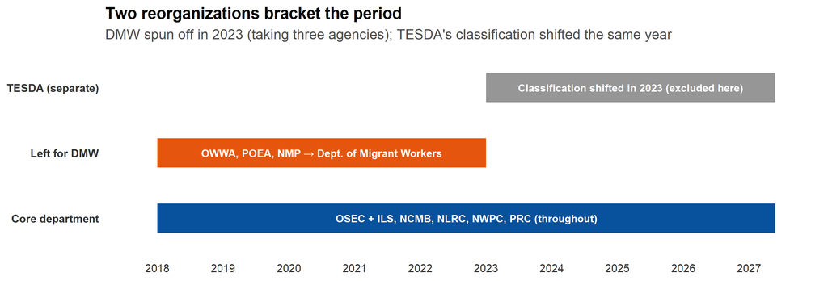

```r
tl <- tibble::tribble(
  ~track, ~label, ~start, ~end, ~fill,
  "Core department",  "OSEC + ILS, NCMB, NLRC, NWPC, PRC (throughout)", 2018, 2027.4, "#08519C",
  "Left for DMW",     "OWWA, POEA, NMP → Dept. of Migrant Workers",     2018, 2023,   "#E6550D",
  "TESDA (separate)", "Classification shifted in 2023 (excluded here)",  2023, 2027.4, "#969696")
ggplot(tl, aes(y = track)) +
  geom_segment(aes(x = start, xend = end, yend = track, color = fill), linewidth = 12, lineend = "butt") +
  scale_color_identity() +
  geom_text(aes(x = (start + end) / 2, label = label), color = "white", fontface = "bold", size = 3.2) +
  scale_x_continuous(breaks = 2018:2027, limits = c(2017.7, 2027.6)) +
  labs(title = "Two reorganizations bracket the period",
       subtitle = "DMW spun off in 2023 (taking three agencies); TESDA's classification shifted the same year",
       x = NULL, y = NULL) +
  theme_dole() + theme(panel.grid.major.y = element_blank(),
        axis.text.y = element_text(face = "bold", color = "grey20"))
```

**The 2023 break matters:** department totals dip as the DMW trio leaves, so any year-to-year comparison across 2022–2023 mixes a structural change with a real budget change.

# 4 The department at a glance

## 4.1 Department budget over time (excluding TESDA)

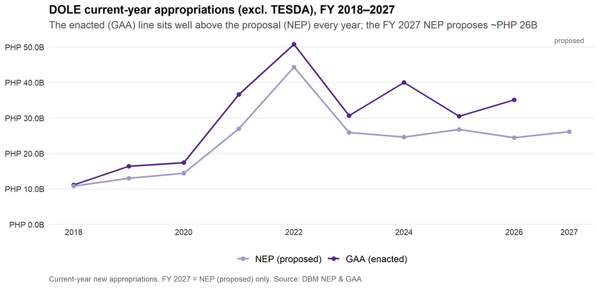

```r
dept <- df_long %>% filter(agency != TESDA_TAB, metric %in% c("NEP","GAA"), !is.na(amount)) %>%
  group_by(year, metric) %>% summarise(total = sum(amount), .groups = "drop") %>%
  mutate(metric = factor(metric, c("NEP","GAA"), c("NEP (proposed)","GAA (enacted)")))
ggplot(dept, aes(year, total, color = metric, group = metric)) +
  geom_line(linewidth = 1) + geom_point(size = 2) + scale_color_manual(values = exec_pal) +
  scale_y_continuous(labels = php_fmt(dept$total), limits = c(0, NA), breaks = pretty_breaks(6), expand = expansion(mult = c(0, .05))) +
  scale_x_continuous(breaks = c(seq(2018, 2026, 2), 2027)) +
  annotate("text", x = 2027, y = Inf, label = "proposed", vjust = 1.4, size = 3, color = "grey45") +
  labs(title = "DOLE current-year appropriations (excl. TESDA), FY 2018–2027",
       subtitle = "The enacted (GAA) line sits well above the proposal (NEP) every year; the FY 2027 NEP proposes ~PHP 26B",
       x = NULL, y = NULL, caption = "Current-year new appropriations. FY 2027 = NEP (proposed) only. Source: DBM NEP & GAA.") +
  theme_dole() + guides(color = guide_legend(nrow = 1))
```

The department roughly **quintupled** at its 2022 peak relative to 2018, then stepped back down — partly because the pandemic scale-up eased, partly because the DMW trio left in 2023. The enacted (GAA) line sits consistently above the proposed (NEP) line: Congress tops DOLE up every year.

## 4.2 Composition by agency

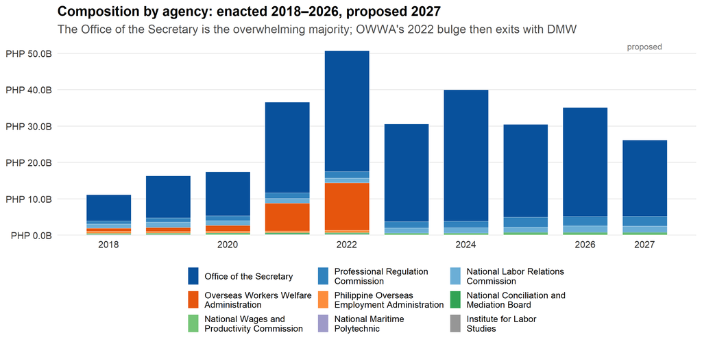

```r
comp <- df_long %>% filter(agency != TESDA_TAB, (metric == "GAA") | (metric == "NEP" & year == 2027), !is.na(amount), amount > 0) %>%
  group_by(year, agency) %>% summarise(amount = sum(amount), .groups = "drop") %>%
  mutate(agency = factor(agency, levels = names(agency_pal)))
ggplot(comp, aes(year, amount, fill = agency)) +
  geom_col(width = 0.75, color = "white", linewidth = 0.2) +
  scale_fill_manual(values = agency_pal, labels = function(x) str_wrap(x, 26)) +
  scale_y_continuous(labels = php_fmt(comp$amount), breaks = pretty_breaks(6), limits = c(0, NA), expand = expansion(mult = c(0, .05))) +
  scale_x_continuous(breaks = c(seq(2018, 2026, 2), 2027)) +
  annotate("text", x = 2027, y = Inf, label = "proposed", vjust = 1.3, size = 3, color = "grey45") +
  labs(title = "Composition by agency: enacted 2018–2026, proposed 2027",
       subtitle = "The Office of the Secretary is the overwhelming majority; OWWA's 2022 bulge then exits with DMW",
       x = NULL, y = NULL) +
  theme_dole() + guides(fill = guide_legend(nrow = 3, byrow = TRUE)) +
  theme(legend.text = element_text(size = 9), legend.key.size = unit(0.4, "cm"))
```

## 4.3 The attached agencies, on their own scale

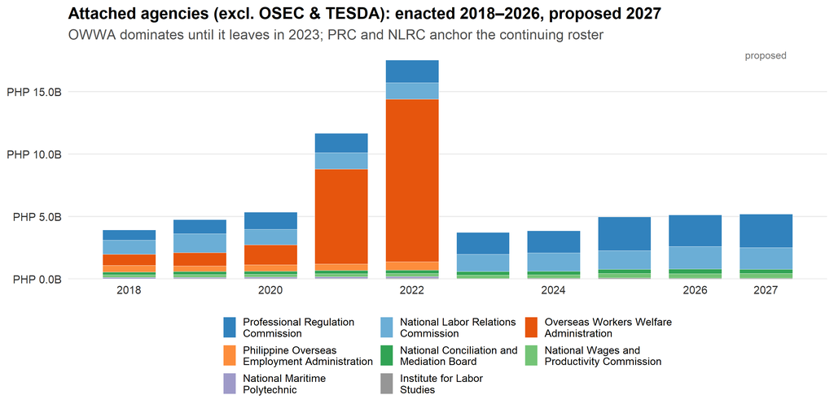

```r
comp2 <- df_long %>% filter(!agency %in% c(TESDA_TAB, "Office of the Secretary"), (metric == "GAA") | (metric == "NEP" & year == 2027), !is.na(amount), amount > 0) %>%
  group_by(year, agency) %>% summarise(amount = sum(amount), .groups = "drop") %>%
  mutate(agency = factor(agency, levels = names(agency_pal)))
ggplot(comp2, aes(year, amount, fill = agency)) +
  geom_col(width = 0.75, color = "white", linewidth = 0.2) +
  scale_fill_manual(values = agency_pal, labels = function(x) str_wrap(x, 26)) +
  scale_y_continuous(labels = php_fmt(comp2$amount), breaks = pretty_breaks(6), limits = c(0, NA), expand = expansion(mult = c(0, .05))) +
  scale_x_continuous(breaks = c(seq(2018, 2026, 2), 2027)) +
  annotate("text", x = 2027, y = Inf, label = "proposed", vjust = 1.3, size = 3, color = "grey45") +
  labs(title = "Attached agencies (excl. OSEC & TESDA): enacted 2018–2026, proposed 2027",
       subtitle = "OWWA dominates until it leaves in 2023; PRC and NLRC anchor the continuing roster",
       x = NULL, y = NULL) +
  theme_dole() + guides(fill = guide_legend(nrow = 3, byrow = TRUE)) +
  theme(legend.text = element_text(size = 9), legend.key.size = unit(0.4, "cm"))
```

With OSEC set aside, the attached agencies are modest — a few billion pesos combined. **OWWA** towers over the rest until 2022; after its exit, **PRC** (the professions’ licensing body) and **NLRC** (labor arbitration) anchor the continuing roster.

## 4.4 The department’s largest P/A/Ps (FY 2027 NEP, proposed)

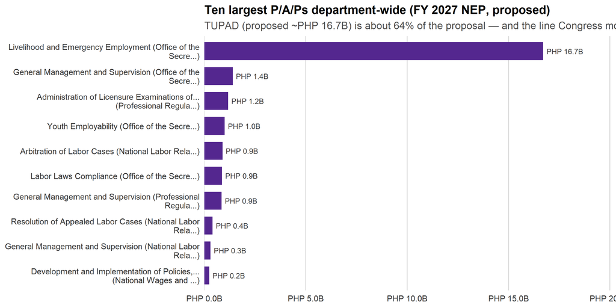

```r
dtp <- df_long %>% filter(agency != TESDA_TAB, metric == "NEP", year == 2027, !is.na(amount), amount > 0) %>%
  mutate(label = paste0(str_trunc(pap, 46), "  (", str_trunc(agency, 22), ")")) %>%
  group_by(label) %>% summarise(amount = sum(amount), .groups = "drop") %>%
  arrange(desc(amount)) %>% slice_head(n = 10) %>% mutate(label = factor(label, levels = rev(label)))
lab <- php_lab(dtp$amount)
ggplot(dtp, aes(label, amount)) + geom_col(fill = "#54278F", width = 0.72) +
  geom_text(aes(label = lab(amount)), hjust = -0.1, size = 3, color = "grey20") + coord_flip() +
  scale_x_discrete(labels = function(x) str_wrap(x, 54)) +
  scale_y_continuous(labels = php_fmt(dtp$amount), expand = expansion(mult = c(0, .2)), limits = c(0, NA)) +
  labs(title = "Ten largest P/A/Ps department-wide (FY 2027 NEP, proposed)",
       subtitle = "TUPAD (proposed ~PHP 16.7B) is about 64% of the proposal — and the line Congress most often tops up",
       x = NULL, y = NULL) +
  theme_dole() + theme(panel.grid.major.y = element_blank(), panel.grid.major.x = element_line(color = "grey85"))
```

The scale gap is the point: TUPAD is larger than every other line in the department **combined**. Everything else — general management, employment facilitation, labor-standards enforcement, the attached agencies’ core functions — shares what is left.

### Every P/A/P: FY 2026 enacted and FY 2027 proposed (interactive)

```r
bind_rows(
  df_long %>% filter(agency != TESDA_TAB, year == 2026, metric == "GAA", !is.na(amount)) %>%
    transmute(agency, pap, col = "GAA2026", amount),
  df_long %>% filter(agency != TESDA_TAB, year == 2027, metric == "NEP", !is.na(amount)) %>%
    transmute(agency, pap, col = "NEP2027", amount)
) %>%
  group_by(agency, pap, col) %>% summarise(amount = sum(amount), .groups = "drop") %>%
  pivot_wider(names_from = col, values_from = amount) %>%
  transmute(Agency = agency, `P/A/P` = pap,
            `FY2026 GAA (M)` = GAA2026 / 1e6, `FY2027 NEP (M)` = NEP2027 / 1e6) %>%
  arrange(desc(`FY2027 NEP (M)`)) %>%
  dt_table(page = 10, money_cols = c("FY2026 GAA (M)", "FY2027 NEP (M)"))
```

| Agency | P/A/P | FY2026 GAA (M) | FY2027 NEP (M) |
| --- | --- | --- | --- |
| Office of the Secretary | Livelihood and Emergency Employment | 25361.555 | 16701.891 |
| Office of the Secretary | General Management and Supervision | 1726.907 | 1405.189 |
| Professional Regulation Commission | Administration of Licensure Examinations of Regulated Professions | 1150.952 | 1175.047 |
| Office of the Secretary | Youth Employability | 1002.05 | 1002.05 |
| National Labor Relations Commission | Arbitration of Labor Cases | 921.391 | 899.723 |
| Office of the Secretary | Labor Laws Compliance | 823.229 | 877.335 |
| Professional Regulation Commission | General Management and Supervision | 777.926 | 854.451 |
| National Labor Relations Commission | Resolution of Appealed Labor Cases | 429.059 | 407.443 |
| National Labor Relations Commission | General Management and Supervision | 325.607 | 303.114 |
| Office of the Secretary | Welfare Services | 221.551 | 228.644 |

[output cut: 33 more lines]